# Top 10 Lap Classification

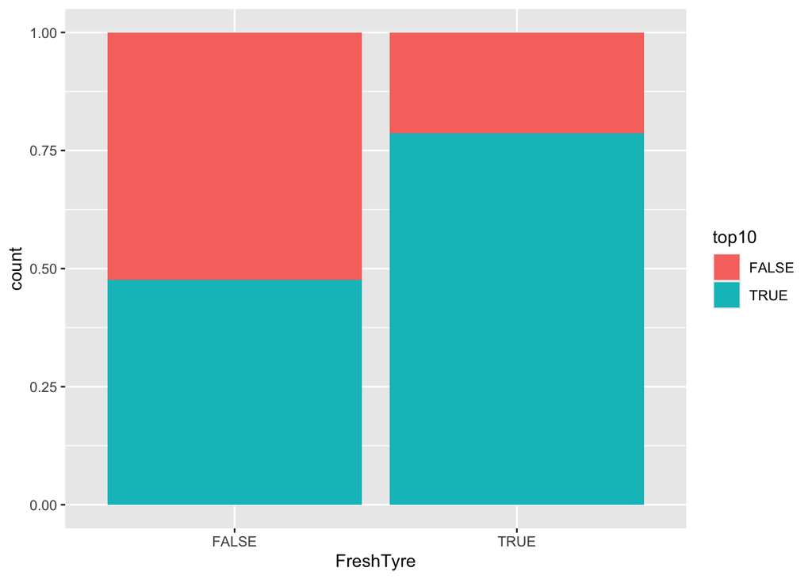

```r
ggplot(data, aes(x = FreshTyre, fill = top10)) +
  geom_bar(position = "fill")
```

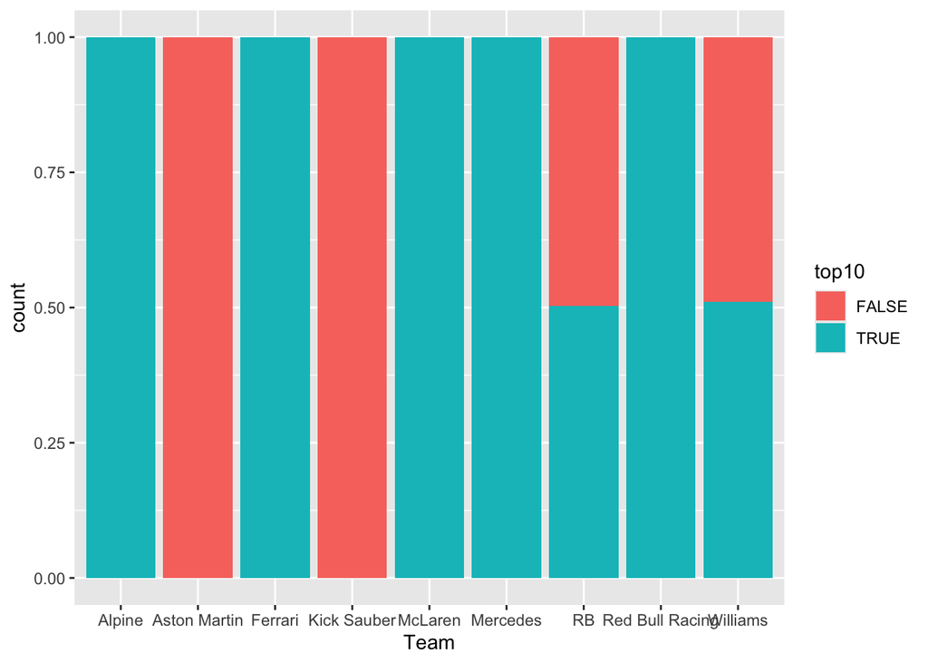

```r
ggplot(data, aes(x = Team, fill = top10)) +
  geom_bar(position = "fill")
```

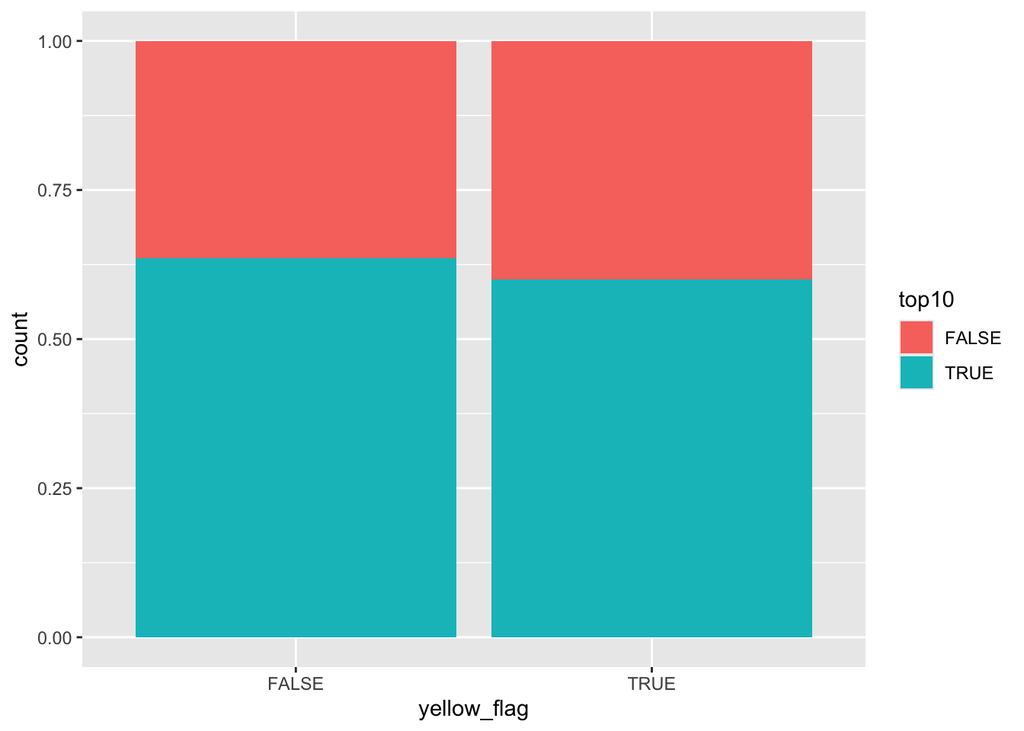

```r
ggplot(data, aes(x = yellow_flag, fill = top10)) +
  geom_bar(position = "fill")
```

he categorical plots showed that some variables, especially `Driver`, `Team`, and `FreshTyre`, have a strong visible relationship with the target variable. However, `Driver` and `Team` should be interpreted carefully, because they may capture general driver or car performance rather than pure lap-level race conditions.

`Stint` may contain useful information related to race strategy and position. `Compound` was more difficult to interpret because there were very few observations with soft tyres. The `yellow_flag` variable did not show a strong visible relationship with the target variable.

Overall, the linearity check suggested that the relationship between predictors and the target variable is not purely linear. This supports the decision to compare Logistic Regression with more flexible nonlinear models.

## 4.9 Results

The exploratory data analysis helped identify the main characteristics and potential issues in the modelling dataset.First, the target variable showed a moderate class imbalance. The Top 10 class represented 63.48% of the observations, while 36.52% of laps were outside the Top 10. This imbalance is not extreme, but it should be considered during model evaluation, so accuracy alone is not sufficient.

The independence check showed that observations are not fully independent, because the dataset contains repeated laps from the same drivers. This limitation should be considered when interpreting the results, although the data can still be used for predictive model comparison.

The collinearity analysis identified strong correlations between several numerical predictors, especially `LapNumber`, `Pressure`, `TrackTemp`, and `TyreLife`. To reduce redundancy, `LapNumber` and `Pressure` were removed, while `TrackTemp` was kept as a more meaningful representative of track conditions.

The normality check showed that the speed-related variables do not closely follow a normal distribution. Since most models considered in this project do not require normally distributed predictors, no transformation was applied at this stage.

The feature scaling check showed that numerical predictors are measured on different scales. Scaling was therefore planned for models that require it, especially SVM, while tree-based models do not require scaling in the same way.

The outlier analysis showed that some variables, especially speed-related variables, contain outlying observations. These outliers were not clearly connected to yellow flag periods or other confirmed race conditions. Therefore, they were kept in the dataset at this stage, with the possibility of checking their effect on model performance later.

Homoscedasticity was not analysed in detail, because it is not a strict assumption for the main models considered in this project. A deeper check would be needed only if models with stronger variance assumptions, such as LDA, were used.

The linearity check suggested that the relationship between predictors and the target variable is not purely linear. This supports the decision to compare a simple interpretable model with more flexible nonlinear models in the next stage of the project.Overall, the EDA provided a basis for selecting a stable and interpretable feature set for modelling, while also highlighting limitations that should be considered when interpreting the final results.

# 5 Modeling Strategy

## 5.1 Classification setup

The task solved in this project is a binary classification problem. The goal is to determine whether a lap belongs to the Top 10 class based on the selected race-related features.

The target variable is `top10`, where `TRUE` means that the lap was completed by a driver in the Top 10, and `FALSE` means that the lap was completed by a driver outside the Top 10.

The priority of the modelling process is to correctly identify as many Top 10 laps as possible. Therefore, sensitivity is treated as one of the most important evaluation metrics. At the same time, the models are not compared only by sensitivity, balanced accuracy, and other performance metrics, but also by their interpretability.

## 5.2 Feature set

For Scenario 1, the same feature set was used for all models. This makes the model comparison more consistent, because differences in performance can be interpreted mainly as differences between modelling approaches, not as a result of using different input variables.

The selected feature set includes:

- `SpeedI2`
- `TyreLife`
- `Stint`
- `SpeedI1`
- `SpeedFL`
- `Compound`

These variables were selected based on the EDA results and their potential relationship with the `top10` target variable.

The `SpeedST` variable was not included in this feature set. It had a relatively high number of outliers and showed less stable behaviour during the exploratory checks. Removing it helped keep the initial feature set simpler and more stable for the first model comparison.

Feature selection itself is analysed separately in Scenario 3. Therefore, Scenario 1 uses one fixed feature set to focus on comparing the modelling methods.

## 5.3 Data Splitting

After selecting the feature set for Scenario 1, a separate dataset was created for modelling. It contains only the selected predictors and the target variable `top10`.

```r
data_sc1 <- data %>% select(SpeedI1, SpeedI2, SpeedFL, TyreLife, Stint, Compound, top10)
```

The data was then split into training, validation, and test sets. A fixed random seed was used to make the split reproducible.

```r
set.seed(13)

data_sc1$top10 <- as.factor(data_sc1$top10)

split <- initial_split(data_sc1, prop = 0.8, strata = top10)

train_val_sc1 <- training(split)
test_sc1 <- testing(split)
```

First, 80% of the data was assigned to the training-validation part, while 20% was kept as the final test set. The split was stratified by `top10`, so the class proportions were preserved as much as possible in both parts.

The training-validation data was then split again into training and validation sets.

```r
set.seed(13)

val_split <- initial_split(train_val_sc1, prop = 0.75, strata = top10)
train_sc1 <- training(val_split)
val_sc1 <- testing(val_split)
```

This produces approximately 60% training data, 20% validation data, and 20% test data. The validation set is used for model comparison and tuning decisions, while the test set is kept separate for final evaluation.

Finally, the class distributions in the training, validation, and test sets were checked to make sure that the stratified split preserved the proportion of `top10` observations.

```r
summary(train_sc1)
```

```
##     SpeedI1         SpeedI2         SpeedFL         TyreLife     Stint
##  Min.   : 96.0   Min.   :154.0   Min.   :184.0   Min.   : 2.00   2:623
##  1st Qu.:185.0   1st Qu.:175.0   1st Qu.:256.0   1st Qu.:15.00   3: 71
##  Median :192.0   Median :181.0   Median :259.0   Median :31.00   4: 14
##  Mean   :191.1   Mean   :181.1   Mean   :259.6   Mean   :33.52
##  3rd Qu.:198.0   3rd Qu.:187.0   3rd Qu.:264.0   3rd Qu.:50.00
##  Max.   :214.0   Max.   :198.0   Max.   :274.0   Max.   :78.00
##    Compound     top10
##  HARD  :459   FALSE:258
##  MEDIUM:234   TRUE :450
##  SOFT  : 15
##
##
##
```

```r
summary(val_sc1)
```

```
##     SpeedI1         SpeedI2         SpeedFL       TyreLife  Stint
##  Min.   :140.0   Min.   :163.0   Min.   :162   Min.   : 2   2:205
##  1st Qu.:186.0   1st Qu.:177.0   1st Qu.:257   1st Qu.:19   3: 29
##  Median :195.0   Median :182.0   Median :258   Median :34   4:  3
##  Mean   :192.5   Mean   :182.2   Mean   :259   Mean   :36
##  3rd Qu.:200.0   3rd Qu.:188.0   3rd Qu.:263   3rd Qu.:53
##  Max.   :212.0   Max.   :199.0   Max.   :274   Max.   :77
##    Compound     top10
##  HARD  :145   FALSE: 87
##  MEDIUM: 85   TRUE :150
##  SOFT  :  7
##
##
##
```

```r
summary(test_sc1)
```

```
##     SpeedI1         SpeedI2         SpeedFL         TyreLife     Stint
##  Min.   :105.0   Min.   :158.0   Min.   :209.0   Min.   : 2.00   2:192
##  1st Qu.:185.2   1st Qu.:178.0   1st Qu.:256.0   1st Qu.:15.00   3: 36
##  Median :194.0   Median :183.0   Median :259.0   Median :32.50   4: 10
##  Mean   :192.3   Mean   :182.8   Mean   :259.4   Mean   :34.44
##  3rd Qu.:201.0   3rd Qu.:189.0   3rd Qu.:263.8   3rd Qu.:50.75
##  Max.   :213.0   Max.   :199.0   Max.   :273.0   Max.   :77.00
##    Compound     top10
##  HARD  :157   FALSE: 87
##  MEDIUM: 71   TRUE :151
##  SOFT  : 10
##
##
##
```

## 5.4 Model Evaluation Metrics

The models are evaluated using the metrics: accuracy, sensitivity, specificity, balanced accuracy, ROC curves, and AUC.

Since the main priority is to correctly identify laps belonging to the Top 10 class, sensitivity is treated as one of the key metrics. However, sensitivity is not interpreted alone, because a model should also keep reasonable performance on the non-Top 10 class. For this reason, specificity and balanced accuracy are also considered.

ROC curves and AUC are used to compare the models across different classification thresholds. This provides a broader view of model performance than a single threshold-based metric.

## 5.5 Selected models

For Scenario 1, three classification models were selected: Logistic Regression, Random Forest, and Support Vector Machine.

Logistic Regression was chosen as a baseline model. It is relatively simple, interpretable, and allows us to understand the direction of the relationship between predictors and the probability of belonging to the Top 10 class. This makes it useful as a reference point for comparing more complex models.

Random Forest was selected as a tree-based nonlinear model. It can capture more complex relationships between predictors and the target variable and does not require strong assumptions about normality or linearity. It also provides feature importance, which is useful for interpretation.

Support Vector Machine was chosen as a flexible classification model that can handle nonlinear decision boundaries, especially when using the radial basis function kernel. Since the EDA suggested that the relationship between predictors and the target variable is not purely linear, SVM provides a useful comparison against both Logistic Regression and Random Forest.

The dataset limitations identified during EDA are not described only in one place. Instead, they are discussed in the relevant model sections, where they directly affect model interpretation or preprocessing decisions. These limitations include class imbalance, repeated laps for the same drivers, nonlinear relationships, outliers, and different feature scales.

# 6. Models

## 6.1 Logistic Regression

Logistic Regression was used as the baseline classification model. This model is suitable for binary classification problems and provides interpretable coefficients, which makes it useful for understanding how the selected predictors are related to the probability of a lap belonging to the Top 10 class.

### Logistic Regression Requirements

Before interpreting the model, the main requirements and limitations were considered.

- Binary response variable The response variable `top10` is binary, with two possible classes: `TRUE` and `FALSE`. Therefore, Logistic Regression is appropriate for this classification task.
- Sample size The training dataset contains 708 lap-level observations. The model uses 6 main predictors, with additional dummy variables created for categorical predictors such as `Stint` and `Compound`. This sample size is sufficient for fitting a basic Logistic Regression model.
- No severe multicollinearity Collinearity was checked during the EDA stage. Strongly correlated variables such as `LapNumber` and `Pressure` were removed before modelling. Therefore, no severe collinearity issue was expected in the final feature set.
- Independence of observations The observations are not fully independent, because the dataset contains repeated laps for the same drivers. This is a limitation of the dataset. However, since the goal is predictive classification and model comparison rather than causal inference, Logistic Regression can still be used as a baseline model.
- Linearity between predictors and log-odds Logistic Regression assumes an approximately linear relationship between numerical predictors and the log-odds of the response variable. The EDA showed that some predictors have nonlinear relationships with the target. This means that Logistic Regression may be limited in capturing more complex patterns, which justifies comparing it with nonlinear models such as Random Forest and SVM.
- Outliers Some speed-related variables contained outliers. These observations were kept in the dataset because no clear data-quality reason was found for removing them. However, Logistic Regression can be affected by influential observations, so this should be considered when interpreting the model.
- Feature scaling Feature scaling is not strictly required for Logistic Regression in the same way as for SVM. Therefore, the model was fitted using the original scale of the selected predictors.

### Model

The model was fitted using the Scenario 1 feature set:

- `SpeedI2`
- `TyreLife`
- `Stint`
- `SpeedI1`
- `SpeedFL`
- `Compound`

```r
lg_model <- glm(data=train_sc1,
  family = binomial,
  top10 ~ SpeedI2 + TyreLife + Stint + SpeedI1 + SpeedFL + Compound
)

summary(lg_model)
```

```
##
## Call:
## glm(formula = top10 ~ SpeedI2 + TyreLife + Stint + SpeedI1 +
##     SpeedFL + Compound, family = binomial, data = train_sc1)
##
## Coefficients:
##                  Estimate Std. Error z value Pr(>|z|)
## (Intercept)    -9.515e+00  5.242e+00  -1.815   0.0695 .
## SpeedI2         2.060e-01  1.855e-02  11.106  < 2e-16 ***
## TyreLife       -3.829e-02  6.732e-03  -5.687 1.29e-08 ***
## Stint3         -3.563e+00  4.715e-01  -7.557 4.13e-14 ***
## Stint4         -8.026e-01  2.471e+03   0.000   0.9997
## SpeedI1         8.611e-03  1.131e-02   0.761   0.4465
## SpeedFL        -1.035e-01  1.854e-02  -5.580 2.41e-08 ***
## CompoundMEDIUM -3.236e-01  2.074e-01  -1.560   0.1187
## CompoundSOFT   -1.883e+01  2.400e+03  -0.008   0.9937
## ---
## Signif. codes:  0 '***' 0.001 '**' 0.01 '*' 0.05 '.' 0.1 ' ' 1
##
## (Dispersion parameter for binomial family taken to be 1)
##
##     Null deviance: 928.77  on 707  degrees of freedom
## Residual deviance: 659.19  on 699  degrees of freedom
## AIC: 677.19
##
## Number of Fisher Scoring iterations: 15
```

The Logistic Regression model shows that several predictors are statistically significant.

`SpeedI2` has a positive coefficient and is statistically significant. This suggests that higher speed at this measurement point is associated with a higher probability of the lap belonging to the Top 10 class.

`TyreLife` has a negative and statistically significant coefficient. This means that, as tyre life increases, the probability of being in the Top 10 class decreases, assuming the other variables remain constant. This is reasonable, because older tyres usually provide lower performance.

`Stint3` is also statistically significant and has a negative coefficient. This suggests that laps in this stint are associated with a lower probability of being in the Top 10 compared with the reference stint.

`SpeedFL` has a negative and statistically significant coefficient. This result should be interpreted carefully, because speed variables can be correlated with race context and may not have a simple direct relationship with the target variable.

`SpeedI1`, `CompoundMEDIUM`, and some sparse categories such as `Stint4` and `CompoundSOFT` are not statistically significant in this model. The very large standard errors for `Stint4` and `CompoundSOFT` suggest that these categories may have very few observations or separation issues. Therefore, their coefficients should not be interpreted as reliable effects.

### Threshold Tuning

By default, Logistic Regression uses a probability threshold of 0.5 for classification. However, it may not always be optimal so, different thresholds were tested on the validation set.

```r
# Threshold tuning
thresholds <- seq(0.05, 0.95, by=0.05)

lg_val_probs <- predict(lg_model, newdata = val_sc1, type="response")

results <- lapply(thresholds, function(t) {

  pred <- ifelse(lg_val_probs >= t, TRUE, FALSE)
  actual <- val_sc1$top10

  TP <- sum(pred == TRUE & actual == TRUE)
  TN <- sum(pred == FALSE & actual == FALSE)
  FP <- sum(pred == TRUE & actual == FALSE)
  FN <- sum(pred == FALSE & actual == TRUE)

  sensitivity <- TP / (TP + FN)
  specificity <- TN / (TN + FP)

  data.frame(
    threshold = t,
    sensitivity = sensitivity,
    specificity = specificity,
    balanced_accuracy = (sensitivity + specificity) / 2
  )
})

results <- bind_rows(results)

results %>% arrange(desc(balanced_accuracy))
```

```
##    threshold sensitivity specificity balanced_accuracy
## 1       0.60   0.8266667   0.6781609         0.7524138
## 2       0.65   0.7733333   0.7241379         0.7487356
## 3       0.70   0.7000000   0.7701149         0.7350575
## 4       0.55   0.8466667   0.6091954         0.7279310
## 5       0.80   0.5800000   0.8620690         0.7210345
## 6       0.50   0.8800000   0.5517241         0.7158621
## 7       0.45   0.9133333   0.5172414         0.7152874
## 8       0.75   0.6266667   0.7931034         0.7098851
## 9       0.40   0.9400000   0.4712644         0.7056322
## 10      0.85   0.5000000   0.9080460         0.7040230
## 11      0.35   0.9600000   0.4367816         0.6983908
## 12      0.30   0.9733333   0.3793103         0.6763218
## 13      0.25   0.9933333   0.3333333         0.6633333
## 14      0.90   0.3266667   0.9655172         0.6460920
## 15      0.20   0.9933333   0.2758621         0.6345977
## 16      0.15   0.9933333   0.2068966         0.6001149
## 17      0.10   1.0000000   0.1609195         0.5804598
## 18      0.05   1.0000000   0.1149425         0.5574713
## 19      0.95   0.1000000   0.9885057         0.5442529
```

The validation results were used to compare sensitivity, specificity, and balanced accuracy across different thresholds. A higher threshold can improve specificity and balanced accuracy, but it may also reduce sensitivity. The 0.6 threshold showed the best result in the balanced_accuracy, keeping the sensitivity at 82.67% and specificity at 67.81% on the validation data.

### Testing

The model’s result on the testing set:

```r
# Testing

lg_probs <- predict(lg_model, newdata = test_sc1, type = "response")

# use the threshold based on the threshold tuning
lg_preds <- ifelse(lg_probs > 0.6, T, F)

confusionMatrix(factor(lg_preds), factor(test_sc1$top10), positive = "TRUE")
```

```
## Confusion Matrix and Statistics
##
##           Reference
## Prediction FALSE TRUE
##      FALSE    60   23
##      TRUE     27  128
##
##                Accuracy : 0.7899
##                  95% CI : (0.7326, 0.8399)
##     No Information Rate : 0.6345
##     P-Value [Acc > NIR] : 1.567e-07
##
##                   Kappa : 0.5426
##
##  Mcnemar's Test P-Value : 0.6714
##
##             Sensitivity : 0.8477
##             Specificity : 0.6897
##          Pos Pred Value : 0.8258
##          Neg Pred Value : 0.7229
##              Prevalence : 0.6345
##          Detection Rate : 0.5378
##    Detection Prevalence : 0.6513
##       Balanced Accuracy : 0.7687
##
##        'Positive' Class : TRUE
##
```

On the test set, the Logistic Regression model reached an accuracy of 0.7899. Since the dataset is not perfectly balanced, accuracy alone is not enough to judge the model, so sensitivity, specificity, and balanced accuracy are also considered.

The model correctly found 128 Top 10 laps and missed 23 of them. This gives a sensitivity of 0.8477, meaning that around 85% of actual Top 10 laps were identified correctly. This is a good result for our goal, because finding Top 10 laps is the main priority.

The specificity is lower, at 0.6897. This means that the model is less accurate when identifying laps outside the Top 10. In practice, some non-Top 10 laps are classified as Top 10. This is the trade-off we accept when sensitivity is more important.

The balanced accuracy is 0.7687, which shows that the model performs reasonably well across both classes, not only on the majority class.

Logistic Regression worked well as a baseline model. It achieved reasonable test performance and, most importantly for this project, showed good sensitivity. This means that the model was able to identify most of the actual Top 10 laps.

### Summary

The main advantage of Logistic Regression is interpretability. The coefficients make it possible to see the direction of the relationship between each predictor and the probability of belonging to the Top 10 class. For example, `SpeedI2` had a positive and significant coefficient, while `TyreLife` had a negative and significant coefficient.However, the model also has some limitations.

The EDA showed that not all relationships between predictors and the target are linear, and Logistic Regression may not capture these nonlinear patterns well. Some categorical levels, such as `Stint4` and `CompoundSOFT`, also had very large standard errors, which suggests that these categories had too few observations or unstable estimates.Overall, Logistic Regression is useful as a simple and interpretable reference model. It gives a clear baseline for comparison, but more flexible models may perform better if the relationship between race features and Top 10 classification is nonlinear.

## 6.2 Random Forest

Random Forest was used as a nonlinear model. Unlike Logistic Regression, it does not assume a linear relationship between predictors and the target variable, which is useful here because the EDA showed that some predictors have nonlinear patterns.

The same feature set as in Logistic Regression was used:

- `SpeedI1`
- `SpeedI2`
- `SpeedFL`
- `TyreLife`
- `Stint`
- `Compound`

This keeps the comparison fair, because the models are fitted on the same input variables.

### Random Forest Requirements and Limitations

- Binary response variable The response variable `top10` is binary, so Random Forest can be used for this classification task.
- Independence of observations The observations are not fully independent, because the dataset contains repeated laps from the same drivers. This is a limitation of the dataset, but it affects the interpretation more than the technical ability to fit the model.
- Linearity is not required Random Forest can model nonlinear relationships between predictors and the target. This is one of the reasons why it was selected after the EDA.
- Normality is not required Random Forest does not require normally distributed predictors, so the non-normality observed in the speed variables is not a major problem for this model.
- Feature scaling is not required Tree-based models split variables by thresholds, so they are not sensitive to feature scales.
- Outliers Random Forest is usually more robust to outliers than Logistic Regression, but outliers can still influence some split decisions. Since no clear data-quality reason was found for removing the outliers, they were kept in the dataset.
- Sample size The training set contains 708 lap-level observations. For this dataset size and the selected feature set, this is enough to fit a Random Forest model.

### Parameter Tuning

For Random Forest, three parameters were tuned:

- `ntree`: the number of trees in the forest;
- `mtry`: the number of variables randomly considered at each split;
- `nodesize`: the minimum size of terminal nodes.

The `maxnodes` parameter was not tuned. Since the dataset is not very large and the number of predictors is limited, `nodesize` was used as the main control for tree complexity.

```r
set.seed(13)

# Parameter tuning
# for the random forest in our case will be enough to tune only the
# ntree, mtry, nodesize
# maxnodes are additional control of the tree depth, but our dataset is not
# that big and there are not many parametrs, so nodesize must be enough

rf_grid <- expand.grid(
  ntree = seq(100, 500, 100),
  mtry = seq(2, 5, 1),
  nodesize = seq(3, 10, 1)
)
```

The models were trained on the training set and evaluated on the validation set. Balanced accuracy was used for selecting the final parameter combination, because it considers both sensitivity and specificity.

```r
rf_results <- lapply(1:nrow(rf_grid), function(i) {
  # to ensure reproducebility, alongside randomness during model building
  set.seed(13 + i)

  model <- randomForest(
    top10 ~ SpeedI2 + TyreLife + Stint + SpeedI1 + SpeedFL + Compound,
    data = train_sc1,
    ntree = rf_grid$ntree[i],
    mtry = rf_grid$mtry[i],
    nodesize = rf_grid$nodesize[i],
    replace = TRUE,
    importance = TRUE
  )

  pred <- predict(model, newdata = val_sc1)
  actual <- val_sc1$top10

  TP <- sum(pred == TRUE & actual == TRUE)
  TN <- sum(pred == FALSE & actual == FALSE)
  FP <- sum(pred == TRUE & actual == FALSE)
  FN <- sum(pred == FALSE & actual == TRUE)

  sensitivity <- TP / (TP + FN)
  specificity <- TN / (TN + FP)

  data.frame(
    ntree = rf_grid$ntree[i],
    mtry = rf_grid$mtry[i],
    nodesize = rf_grid$nodesize[i],
    sensitivity = sensitivity,
    specificity = specificity,
    balanced_accuracy = (sensitivity + specificity) / 2
  )
})

rf_results <- bind_rows(rf_results)

rf_results %>%
  arrange(desc(balanced_accuracy)) %>%
  head(n=30)
```

```
##    ntree mtry nodesize sensitivity specificity balanced_accuracy
## 1    100    5        3   0.8933333   0.8160920         0.8547126
## 2    200    4        3   0.9133333   0.7931034         0.8532184
## 3    100    4        4   0.9133333   0.7931034         0.8532184
## 4    300    4        7   0.9133333   0.7931034         0.8532184
## 5    400    5        5   0.9000000   0.8045977         0.8522989
## 6    300    5        6   0.9000000   0.8045977         0.8522989
## 7    200    3        5   0.9066667   0.7931034         0.8498851
## 8    200    5        6   0.9066667   0.7931034         0.8498851
## 9    300    4        3   0.9133333   0.7816092         0.8474713
## 10   200    3        4   0.9133333   0.7816092         0.8474713
## 11   300    4        4   0.9133333   0.7816092         0.8474713
## 12   100    4        5   0.9000000   0.7931034         0.8465517
## 13   400    5        6   0.9000000   0.7931034         0.8465517
## 14   300    3        3   0.9200000   0.7701149         0.8450575
```

[output cut: 16 more lines]

```r
# find the number of the row with the best accuracy to get the number of the seed
# in our situation its 16
rf_results %>%
  head(n=30)
```

```
##    ntree mtry nodesize sensitivity specificity balanced_accuracy
## 1    100    2        3   0.9266667   0.6896552         0.8081609
## 2    200    2        3   0.9133333   0.7126437         0.8129885
## 3    300    2        3   0.9266667   0.7011494         0.8139080
## 4    400    2        3   0.9266667   0.7126437         0.8196552
## 5    500    2        3   0.9133333   0.7241379         0.8187356
## 6    100    3        3   0.9000000   0.7586207         0.8293103
## 7    200    3        3   0.9133333   0.7701149         0.8417241
## 8    300    3        3   0.9200000   0.7701149         0.8450575
## 9    400    3        3   0.9066667   0.7816092         0.8441379
## 10   500    3        3   0.9133333   0.7471264         0.8302299
## 11   100    4        3   0.8933333   0.7931034         0.8432184
## 12   200    4        3   0.9133333   0.7931034         0.8532184
## 13   300    4        3   0.9133333   0.7816092         0.8474713
## 14   400    4        3   0.9066667   0.7816092         0.8441379
```

[output cut: 16 more lines]

The best validation result was achieved with:

- `ntree = 100`
- `mtry = 5`
- `nodesize = 3`

This model reached a validation sensitivity of 0.8933, specificity of 0.8161, and balanced accuracy of 0.8547. These values show a good balance between finding Top 10 laps and correctly identifying laps outside the Top 10.

### Training

The final Random Forest model was fitted using the best parameter combination from the validation results.

```r
set.seed(13 + 16)

rf_model <- randomForest(
  top10 ~ SpeedI2 + TyreLife + Stint + SpeedI1 + SpeedFL + Compound,
  data = train_sc1,
  ntree = 100,
  mtry = 5,
  nodesize = 3,
  replace = TRUE,
  importance = TRUE
)
```

### Feature Importance

Random Forest also provides feature importance values, which help to understand which predictors contributed more to the model.

```r
rf_model$importance
```

```
##               FALSE       TRUE MeanDecreaseAccuracy MeanDecreaseGini
## SpeedI2  0.18518789 0.13231226           0.15133996         90.31792
## TyreLife 0.07505993 0.03827195           0.05192831         53.24394
## Stint    0.05381771 0.05927127           0.05715783         21.23272
## SpeedI1  0.05560201 0.06697303           0.06277028         54.52434
## SpeedFL  0.10285647 0.12119261           0.11418636         73.80912
## Compound 0.03193322 0.01595512           0.02180863         13.97074
```

The most important variables were `SpeedI2` and `SpeedFL`. Both of them had high importance values, which suggests that speed-related information is strongly connected with the Top 10 classification.

`TyreLife`, `SpeedI1`, and `Stint` also contributed to the model, although less strongly than `SpeedI2` and `SpeedFL`. This makes sense, because tyre age and stint can reflect race strategy and tyre performance during the race.

`Compound` had the lowest importance among the selected predictors. This does not necessarily mean that tyre compound has no effect at all, but in this dataset and with this model it added less information than the speed and tyre-life variables.

### Testing

```r
rf_preds <- predict(rf_model, newdata = test_sc1)

confusionMatrix(rf_preds, test_sc1$top10, positive = "TRUE")
```

```
## Confusion Matrix and Statistics
##
##           Reference
## Prediction FALSE TRUE
##      FALSE    70    9
##      TRUE     17  142
##
##                Accuracy : 0.8908
##                  95% CI : (0.844, 0.9274)
##     No Information Rate : 0.6345
##     P-Value [Acc > NIR] : <2e-16
##
##                   Kappa : 0.7598
##
##  Mcnemar's Test P-Value : 0.1698
##
##             Sensitivity : 0.9404
##             Specificity : 0.8046
##          Pos Pred Value : 0.8931
##          Neg Pred Value : 0.8861
##              Prevalence : 0.6345
##          Detection Rate : 0.5966
##    Detection Prevalence : 0.6681
##       Balanced Accuracy : 0.8725
##
##        'Positive' Class : TRUE
##
```

On the test set, Random Forest performed clearly better than the Logistic Regression baseline. The model reached an accuracy of 0.8908 and a balanced accuracy of 0.8725.

The model correctly identified 142 Top 10 laps and missed only 9 of them. This gives a sensitivity of 0.9404, which is very strong for the main goal of the project.

The specificity was 0.8046, meaning that the model also performed well on laps outside the Top 10. There were 17 non-Top 10 laps incorrectly classified as Top 10, but this is still a clear improvement compared with the Logistic Regression model.

Overall, Random Forest gives a better balance between sensitivity and specificity. It keeps high sensitivity, which is important for detecting Top 10 laps, while also improving the classification of non-Top 10 laps.

### Summary

Random Forest performed well on this classification task. It handled the nonlinear relationships better than Logistic Regression and achieved stronger test performance. The model is less directly interpretable than Logistic Regression, but the feature importance results still provide useful information about which variables were most relevant.

The main limitation is that Random Forest does not explain the direction of the relationship as clearly as Logistic Regression. For example, it can show that `SpeedI2` is important, but it does not directly explain whether increasing `SpeedI2` always increases the probability of being in the Top 10. Therefore, the model is useful for prediction and feature ranking, but less transparent for coefficient-level interpretation.

# 6.3 Support Vector Machine

Support Vector Machine was used as another nonlinear classification model. Since the EDA showed that some predictors do not have a clearly linear relationship with the target variable, an SVM with a radial kernel was selected. The radial kernel allows the model to create a nonlinear decision boundary, which can be useful for this classification task.

The same feature set was used as in the previous models:

- `SpeedI1`
- `SpeedI2`
- `SpeedFL`
- `TyreLife`
- `Stint`
- `Compound`

This keeps the comparison consistent across Logistic Regression, Random Forest, and SVM.

### Feature Scaling

Before fitting the SVM model, the numerical predictors were scaled. This step was needed because SVM is sensitive to the scale of the input variables.

Only the numerical variables were scaled:

- `SpeedI2`
- `SpeedI1`
- `SpeedFL`
- `TyreLife`

The categorical variables `Stint` and `Compound` were kept as factors.

```r
num_features <- c("SpeedI2", "SpeedI1", "SpeedFL", "TyreLife")

train_means <- train_sc1 %>%
  summarise(
    across(
      where(is.numeric),
      mean,
      na.rm = T
    )
  )

train_sds <- train_sc1 %>%
  summarise(
    across(
      where(is.numeric),
      sd,
      na.rm = T
    )
  )

scale <- function(data, means, sds, features) {
  scaled <- data

  for (f in features) {
    scaled[[f]] <- (data[[f]] - means[[f]]) / sds[[f]]
  }

  scaled
}

# scale all sets based on the train set, to prevent leakage
train_svm <- scale(train_sc1, train_means, train_sds, num_features)
val_svm <- scale(val_sc1, train_means, train_sds, num_features)
test_svm <- scale(test_sc1, train_means, train_sds, num_features)
```

The scaling parameters were calculated only from the training set. This is important because using validation or test data to calculate means and standard deviations would create data leakage. The same training-set scaling parameters were then applied to the validation and test sets. This keeps the workflow realistic and prevents information from the validation or test data from entering the training process.

### Parameter Tuning

For the SVM model, three main parameters were tuned:

- `cost`: controls how strongly the model penalizes misclassification;
- `gamma`: controls the flexibility of the radial decision boundary.
- `kernel`: controls how the data is transformed

A grid of possible values was tested on the validation set.

```r
set.seed(13)

svm_grid <- expand.grid(
  cost = seq(0.5, 10, 0.5),
  gamma = seq(0.005, 1, 0.05),
  kernel = c("radial", "linear", "polynomial", "sigmoid")
)

svm_grid %>% head(n = 30)
```

```
##    cost gamma kernel
## 1   0.5 0.005 radial
## 2   1.0 0.005 radial
## 3   1.5 0.005 radial
## 4   2.0 0.005 radial
## 5   2.5 0.005 radial
## 6   3.0 0.005 radial
## 7   3.5 0.005 radial
## 8   4.0 0.005 radial
## 9   4.5 0.005 radial
## 10  5.0 0.005 radial
## 11  5.5 0.005 radial
## 12  6.0 0.005 radial
## 13  6.5 0.005 radial
## 14  7.0 0.005 radial
```

[output cut: 16 more lines]

```r
svm_results <- lapply(1:nrow(svm_grid), function(i) {

   model <- svm(
    top10 ~ SpeedI2 + TyreLife + Stint + SpeedI1 + SpeedFL + Compound,
    data = train_svm,
    kernel = svm_grid$kernel[i],
    cost = svm_grid$cost[i],
    gamma = svm_grid$gamma[i],
  )

  pred <- predict(model, newdata = val_svm)
  actual <- val_svm$top10

  TP <- sum(pred == TRUE & actual == TRUE)
  TN <- sum(pred == FALSE & actual == FALSE)
  FP <- sum(pred == TRUE & actual == FALSE)
  FN <- sum(pred == FALSE & actual == TRUE)

  sensitivity <- TP / (TP + FN)
  specificity <- TN / (TN + FP)

  data.frame(
    cost = svm_grid$cost[i],
    gamma = svm_grid$gamma[i],
    kernel = svm_grid$kernel[i],
    sensitivity = sensitivity,
    specificity = specificity,
    balanced_accuracy = (sensitivity + specificity) / 2
  )
})

svm_results <- bind_rows(svm_results)

svm_results %>%
  arrange(desc(balanced_accuracy)) %>%
  head(n = 30)
```

```
##    cost gamma kernel sensitivity specificity balanced_accuracy
## 1   9.0 0.955 radial   0.8933333   0.7931034         0.8432184
## 2   9.5 0.955 radial   0.8933333   0.7931034         0.8432184
## 3  10.0 0.955 radial   0.8933333   0.7931034         0.8432184
## 4   6.5 0.155 radial   0.9466667   0.7241379         0.8354023
## 5   7.0 0.155 radial   0.9466667   0.7241379         0.8354023
## 6  10.0 0.905 radial   0.8866667   0.7816092         0.8341379
## 7   7.5 0.955 radial   0.8866667   0.7816092         0.8341379
## 8   8.0 0.955 radial   0.8866667   0.7816092         0.8341379
## 9   8.5 0.955 radial   0.8866667   0.7816092         0.8341379
## 10  8.0 0.655 radial   0.9066667   0.7586207         0.8326437
## 11  7.5 0.705 radial   0.9066667   0.7586207         0.8326437
## 12  5.0 0.955 radial   0.9066667   0.7586207         0.8326437
## 13  2.0 0.155 radial   0.9400000   0.7241379         0.8320690
## 14  4.5 0.155 radial   0.9400000   0.7241379         0.8320690
```

[output cut: 16 more lines]

Each parameter combination was fitted on the training set and evaluated on the validation set. Balanced accuracy was used to choose the best combination, because it considers both sensitivity and specificity.

The best validation result was obtained with `kernel = radial` cost = 9`and`gamma = 0.955`. This combination reached a validation sensitivity of 0.8933, specificity of 0.7931, and balanced accuracy of 0.8432.

This result shows that the SVM model performs well on the validation set, although it did not improve over the best Random Forest validation result.

### Testing

The final SVM model was fitted using the best parameter combination from the validation results.

```r
svm_model <- svm(
  top10 ~ SpeedI2 + TyreLife + Stint + SpeedI1 + SpeedFL + Compound,
  data = train_svm,
  kernel = "radial",
  cost = 9,
  gamma = 0.955,
  probability = TRUE
)

# No check of the Feature Importance due to the radial kernel chosen
# these option doesn't provide a clear data about the significance of the features

svm_preds <- predict(svm_model, newdata = test_svm)

confusionMatrix(svm_preds, test_svm$top10, positive = "TRUE")
```

```
## Confusion Matrix and Statistics
##
##           Reference
## Prediction FALSE TRUE
##      FALSE    72   10
##      TRUE     15  141
##
##                Accuracy : 0.895
##                  95% CI : (0.8488, 0.9309)
##     No Information Rate : 0.6345
##     P-Value [Acc > NIR] : <2e-16
##
##                   Kappa : 0.7707
##
##  Mcnemar's Test P-Value : 0.4237
##
##             Sensitivity : 0.9338
##             Specificity : 0.8276
##          Pos Pred Value : 0.9038
##          Neg Pred Value : 0.8780
##              Prevalence : 0.6345
##          Detection Rate : 0.5924
##    Detection Prevalence : 0.6555
##       Balanced Accuracy : 0.8807
##
##        'Positive' Class : TRUE
##
```

Because a radial kernel was used, the model does not provide coefficients that can be interpreted in the same direct way as Logistic Regression. Therefore, no feature importance interpretation was used for this model.

On the test set, the SVM model reached an accuracy of 0.8950 and a balanced accuracy of 0.8807. This is a strong result and shows that the model performs well on both classes.

The model correctly identified 141 Top 10 laps and missed only 10 of them. This gives a sensitivity of 0.9338, which fits well with the main goal of the project: finding as many Top 10 laps as possible.

The specificity was 0.8276, meaning that the model also classified non-Top 10 laps quite well. There were 15 non-Top 10 laps incorrectly predicted as Top 10.

Overall, the SVM model gives a good balance between sensitivity and specificity. It performs slightly better than Random Forest in terms of balanced accuracy on the test set, while keeping very high sensitivity.

### Summary

SVM with a radial kernel worked well for this classification task. It reached high sensitivity, which is important because the main goal is to identify Top 10 laps. At the same time, it also kept good specificity, so the model was not only predicting the majority class.

The main advantage of this model is that it can handle nonlinear relationships between predictors and the target. This is useful here, because the EDA showed that not all predictors have a simple linear relationship with `top10`.

The main limitation is interpretability. Unlike Logistic Regression, the radial SVM does not provide simple coefficients, and unlike Random Forest, it does not give a straightforward feature importance table. Therefore, SVM is useful mainly as a strong predictive model, but it is harder to explain in terms of individual feature effects.

Overall, SVM provided the strongest test performance among the three models, but this comes with lower interpretability.

# 6.4 Model Comparison

After fitting all three models, their overall classification performance was compared using ROC curves and AUC values.

ROC curves were used because they show the trade-off between sensitivity and specificity across different classification thresholds. This makes them useful for comparing models more broadly than a single confusion matrix result.

```r
lg_probs %>% head(n=30)
```

```
##         1         2         3         4         5         6         7         8
## 0.9063355 0.9048769 0.9370909 0.9036515 0.9110036 0.9577245 0.7336892 0.8516431
##         9        10        11        12        13        14        15        16
## 0.9326558 0.8207667 0.7927404 0.8902083 0.8475399 0.9076019 0.8347817 0.7617548
##        17        18        19        20        21        22        23        24
## 0.9287658 0.9469172 0.9512685 0.9124094 0.9096935 0.7471753 0.9959706 0.7445976
##        25        26        27        28        29        30
## 0.7239346 0.8722978 0.8207934 0.9097595 0.7510872 0.9195579
```

```r
rf_probs <- predict(rf_model, newdata = test_sc1, type="prob")[, "TRUE"]
rf_probs %>% head(n = 30)
```

```
##    1    2    3    4    5    6    7    8    9   10   11   12   13   14   15   16
## 0.98 0.99 0.78 0.69 0.63 0.52 0.65 0.98 0.73 0.62 0.64 0.93 0.86 0.90 0.87 0.86
##   17   18   19   20   21   22   23   24   25   26   27   28   29   30
## 0.91 0.87 0.89 1.00 1.00 0.77 0.38 0.87 0.82 0.97 1.00 0.92 0.80 0.93
```

```r
svm_probs <- predict(svm_model, newdata = test_svm, probability = TRUE)
svm_probs <- attr(svm_probs, "probabilities")[, "TRUE"]
svm_probs %>% head(n=30)
```

```
##         1         2         3         4         5         6         7         8
## 0.9556072 0.8888985 0.8856831 0.8294819 0.7959056 0.9082783 0.5801864 0.9125284
##         9        10        11        12        13        14        15        16
## 0.9846017 0.7764190 0.7405067 0.9895487 0.9570803 0.9857332 0.9325464 0.6937278
##        17        18        19        20        21        22        23        24
## 0.6159111 0.9138591 0.9390658 0.9656274 0.9476094 0.9767009 0.4975336 0.9332228
##        25        26        27        28        29        30
## 0.9771435 0.9560722 0.9819650 0.9561285 0.8895850 0.9376312
```

```r
roc_lg <- roc(test_sc1$top10, lg_probs)
roc_rf <- roc(test_sc1$top10, rf_probs)
roc_svm <- roc(test_svm$top10, svm_probs)
auc(roc_lg)
```

```
## Area under the curve: 0.8834
```

```r
auc(roc_rf)
```

```
## Area under the curve: 0.9335
```

```r
auc(roc_svm)
```

```
## Area under the curve: 0.946
```

The AUC values were:

- Logistic Regression: 0.8834
- Random Forest: 0.9335
- SVM: 0.9460

These results show that all three models performed well, since all AUC values are well above 0.5. However, there is a clear difference between the simpler baseline model and the more flexible nonlinear models.

Logistic Regression achieved the lowest AUC. This is still a solid result, but it suggests that a simple linear decision boundary is not able to capture the full structure of the data.

Random Forest improved the performance noticeably. Its AUC of 0.9335 shows that the model captures the relationship between the predictors and the target much better than Logistic Regression.

SVM achieved the highest AUC, although the difference compared with Random Forest is quite small. This suggests that allowing a flexible nonlinear decision boundary is useful for this task.

The ROC curves support the same conclusion visually.

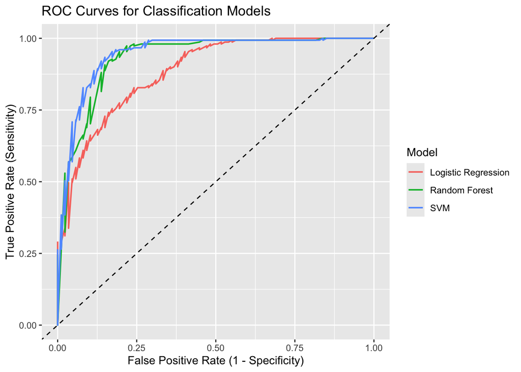

```r
roc_df <- bind_rows(
  data.frame(
    specificity = roc_lg$specificities,
    sensitivity = roc_lg$sensitivities,
    model = "Logistic Regression"
  ),
  data.frame(
    specificity = roc_rf$specificities,
    sensitivity = roc_rf$sensitivities,
    model = "Random Forest"
  ),
  data.frame(
    specificity = roc_svm$specificities,
    sensitivity = roc_svm$sensitivities,
    model = "SVM"
  )
) %>%
  mutate(
    false_positive_rate = 1 - specificity
  )

ggplot(roc_df, aes(x = false_positive_rate, y = sensitivity, color = model)) +
  geom_line(linewidth = 0.7) +
  geom_abline(linetype = "dashed") +
  labs(
    title = "ROC Curves for Classification Models",
    x = "False Positive Rate (1 - Specificity)",
    y = "True Positive Rate (Sensitivity)",
    color = "Model"
  )
```

The SVM and Random Forest curves stay closer to the top-left corner of the plot, which indicates stronger classification performance. The Logistic Regression curve is clearly lower, which is consistent with the weaker AUC value.

Overall, the comparison shows a clear trade-off between interpretability and predictive performance. Logistic Regression is the easiest model to interpret, but it gives the weakest predictive results. Random Forest and SVM both improve performance substantially. Among them, SVM achieved the best overall performance, while Random Forest remained very close and offered somewhat better interpretability through feature importance.

## 6.5 First Scenario Summary

The comparison of the three classification models shows that model flexibility matters for this task. Logistic Regression provided a useful and interpretable baseline, but its performance was clearly lower than the nonlinear models.

Random Forest and SVM both performed strongly, with high sensitivity, balanced accuracy, and AUC. SVM achieved the best overall results, but only by a small margin over Random Forest.

This means that if the priority is predictive performance, SVM is the strongest choice in Scenario 1. If a better balance between performance and interpretability is preferred, Random Forest can also be considered a strong option.

# 7. Feature Selection

In Scenario 3, feature selection is analysed for the same classification task. The goal is to check which predictors are useful for identifying Top 10 laps and whether a smaller feature set can keep similar model performance.

This part is not only about removing variables. It is also used to compare how different feature selection methods behave. A feature may look unimportant in one model, but still be useful in another model. Because of this, feature selection is checked separately for Logistic Regression and Random Forest.

The same train, validation, and test split from Scenario 1 is used here, so the results can be compared in a consistent way.

## 7.1 Stepwise Logistic Regression

The first feature selection step was done using Logistic Regression. Since Logistic Regression is an interpretable model, it is useful not only for prediction, but also for checking which predictors have a clear statistical contribution.

Two approaches were used:

1. stepwise selection based on AIC;
2. reduction based on statistical significance of the coefficients.

The purpose was to check whether the full feature set from Scenario 1 can be simplified without losing too much predictive performance.

### Full Logistic Regression Model

First, the full Logistic Regression model was evaluated using the original feature set from Scenario 1.

```r
lg_probs <- predict(lg_model, newdata = test_sc1, type = "response")

roc_lg <- roc(test_sc1$top10, lg_probs)
lg_preds <- ifelse(lg_probs > 0.6, T, F)

# Metrics
confusionMatrix(factor(lg_preds), factor(test_sc1$top10), positive = "TRUE")
```

```
## Confusion Matrix and Statistics
##
##           Reference
## Prediction FALSE TRUE
##      FALSE    60   23
##      TRUE     27  128
##
##                Accuracy : 0.7899
##                  95% CI : (0.7326, 0.8399)
##     No Information Rate : 0.6345
##     P-Value [Acc > NIR] : 1.567e-07
##
##                   Kappa : 0.5426
##
##  Mcnemar's Test P-Value : 0.6714
##
##             Sensitivity : 0.8477
##             Specificity : 0.6897
##          Pos Pred Value : 0.8258
##          Neg Pred Value : 0.7229
##              Prevalence : 0.6345
##          Detection Rate : 0.5378
##    Detection Prevalence : 0.6513
##       Balanced Accuracy : 0.7687
##
##        'Positive' Class : TRUE
##
```

```r
AIC(lg_model)
```

```
## [1] 677.193
```

```r
auc(roc_lg)
```

```
## Area under the curve: 0.8834
```

### Stepwise Logistic Regression

Stepwise Logistic Regression was used as an algorithmic feature selection method. The model started with the full Logistic Regression model from Scenario 1 and then tested whether adding or removing predictors improved the AIC.

```r
step_model <- step(
  lg_model,
  direction = "both",
  trace=TRUE
)
```

```
## Start:  AIC=677.19
## top10 ~ SpeedI2 + TyreLife + Stint + SpeedI1 + SpeedFL + Compound
##
##            Df Deviance    AIC
## - SpeedI1   1   659.78 675.78
## <none>          659.19 677.19
## - Compound  2   665.97 679.97
## - TyreLife  1   696.14 712.14
## - SpeedFL   1   700.53 716.53
## - Stint     2   737.31 751.31
## - SpeedI2   1   837.16 853.16
##
## Step:  AIC=675.78
## top10 ~ SpeedI2 + TyreLife + Stint + SpeedFL + Compound
##
##            Df Deviance    AIC
## <none>          659.78 675.78
## + SpeedI1   1   659.19 677.19
## - Compound  2   666.22 678.22
## - TyreLife  1   699.54 713.54
## - SpeedFL   1   701.13 715.13
## - Stint     2   737.64 749.64
## - SpeedI2   1   846.89 860.89
```

The stepwise procedure suggested removing `SpeedI1`. The full model had an AIC of 677.19, while the model without `SpeedI1` had a slightly lower AIC of 675.78. This means that removing `SpeedI1` made the model a little simpler and slightly better according to AIC.

It is also interesting that `Compound` stayed in the model, even though its individual levels were not statistically significant in the Logistic Regression summary. This can happen because stepwise selection evaluates the model as a whole. A variable may not look significant on its own, but it can still slightly improve the model in combination with other predictors. However, this result should be interpreted only as a Logistic Regression-based selection. It does not mean that the same reduced feature set will also be best for Random Forest or SVM.

Based on the stepwise result, a reduced Logistic Regression model was fitted without `SpeedI1`.

```r
lg_step_model <- glm(data=train_sc1,
                family = binomial,
                top10 ~ SpeedI2 + TyreLife + Stint + SpeedFL + Compound
)

lg_step_probs <- predict(lg_step_model, newdata = test_sc1, type="response")

roc_step_lg <- roc(test_sc1$top10, lg_step_probs)
lg_step_preds <- ifelse(lg_step_probs > 0.6, T, F)

confusionMatrix(factor(lg_step_preds), factor(test_sc1$top10), positive ="TRUE")
```

```
## Confusion Matrix and Statistics
##
##           Reference
## Prediction FALSE TRUE
##      FALSE    62   20
##      TRUE     25  131
##
##                Accuracy : 0.8109
##                  95% CI : (0.7553, 0.8586)
##     No Information Rate : 0.6345
##     P-Value [Acc > NIR] : 2.246e-09
##
##                   Kappa : 0.5873
##
##  Mcnemar's Test P-Value : 0.551
##
##             Sensitivity : 0.8675
##             Specificity : 0.7126
##          Pos Pred Value : 0.8397
##          Neg Pred Value : 0.7561
##              Prevalence : 0.6345
##          Detection Rate : 0.5504
##    Detection Prevalence : 0.6555
##       Balanced Accuracy : 0.7901
##
##        'Positive' Class : TRUE
##
```

```r
AIC(lg_step_model)
```

```
## [1] 675.785
```

```r
auc(roc_step_lg)
```

```
## Area under the curve: 0.8843
```

fter removing `SpeedI1`, the model became slightly better than the full Logistic Regression model. The AIC decreased from 677.19 to 675.79

The test performance also improved. Accuracy increased from 0.7899 to 0.8109, sensitivity increased from 0.8477 to 0.8675, and specificity increased from 0.6897 to 0.7126. Balanced accuracy also improved from 0.7687 to 0.7901.

This means that removing `SpeedI1` made the model simpler and also improved its test performance. For Logistic Regression, `SpeedI1` does not seem to add useful information once the other predictors are already included.

### Reduction Based on Statistical Significance

The Logistic Regression model was also checked using the statistical significance of the coefficients.

```r
# Reduce by the significance of the features
# The full model, insignificant:
# SpeedI1, CompoundSoft, CompoundMedium and Stint4
summary(lg_model)
```

```
##
## Call:
## glm(formula = top10 ~ SpeedI2 + TyreLife + Stint + SpeedI1 +
##     SpeedFL + Compound, family = binomial, data = train_sc1)
##
## Coefficients:
##                  Estimate Std. Error z value Pr(>|z|)
## (Intercept)    -9.515e+00  5.242e+00  -1.815   0.0695 .
## SpeedI2         2.060e-01  1.855e-02  11.106  < 2e-16 ***
## TyreLife       -3.829e-02  6.732e-03  -5.687 1.29e-08 ***
## Stint3         -3.563e+00  4.715e-01  -7.557 4.13e-14 ***
## Stint4         -8.026e-01  2.471e+03   0.000   0.9997
## SpeedI1         8.611e-03  1.131e-02   0.761   0.4465
## SpeedFL        -1.035e-01  1.854e-02  -5.580 2.41e-08 ***
## CompoundMEDIUM -3.236e-01  2.074e-01  -1.560   0.1187
## CompoundSOFT   -1.883e+01  2.400e+03  -0.008   0.9937
## ---
## Signif. codes:  0 '***' 0.001 '**' 0.01 '*' 0.05 '.' 0.1 ' ' 1
##
## (Dispersion parameter for binomial family taken to be 1)
##
##     Null deviance: 928.77  on 707  degrees of freedom
## Residual deviance: 659.19  on 699  degrees of freedom
## AIC: 677.19
##
## Number of Fisher Scoring iterations: 15
```

```r
# Results on the model without SpeedI1, insignificant:
# Stint4, CompoundMedium, CompoundSoft
# Remove the Compound on this step, because Stint and Compound are factors,
# but Stint3 is significant, while both Compounds are insignificant
summary(lg_step_model)
```

```
##
## Call:
## glm(formula = top10 ~ SpeedI2 + TyreLife + Stint + SpeedFL +
##     Compound, family = binomial, data = train_sc1)
##
## Coefficients:
##                  Estimate Std. Error z value Pr(>|z|)
## (Intercept)    -8.193e+00  4.977e+00  -1.646   0.0997 .
## SpeedI2         2.076e-01  1.845e-02  11.249  < 2e-16 ***
## TyreLife       -3.604e-02  5.983e-03  -6.024 1.70e-09 ***
## Stint3         -3.470e+00  4.471e-01  -7.761 8.45e-15 ***
## Stint4         -8.827e-01  2.471e+03   0.000   0.9997
## SpeedFL        -1.036e-01  1.862e-02  -5.566 2.61e-08 ***
## CompoundMEDIUM -3.128e-01  2.071e-01  -1.511   0.1309
## CompoundSOFT   -1.867e+01  2.400e+03  -0.008   0.9938
## ---
## Signif. codes:  0 '***' 0.001 '**' 0.01 '*' 0.05 '.' 0.1 ' ' 1
##
## (Dispersion parameter for binomial family taken to be 1)
##
##     Null deviance: 928.77  on 707  degrees of freedom
## Residual deviance: 659.78  on 700  degrees of freedom
## AIC: 675.78
##
## Number of Fisher Scoring iterations: 15
```

In the full model, `SpeedI1`, `CompoundMEDIUM`, `CompoundSOFT`, and `Stint4` were not statistically significant. After removing `SpeedI1`, the remaining insignificant terms were `Stint4`, `CompoundMEDIUM`, and `CompoundSOFT`.

Since `Stint` and `Compound` are factor variables, they should not be judged only by one individual dummy coefficient. `Stint` was kept because one of its levels was significant, while both levels of `Compound` were insignificant. Because of this, a second reduced model was fitted without `Compound`.

```r
lg_reduced_model <- glm(data=train_sc1,
                        family = binomial,
                        top10 ~ SpeedI2 + TyreLife + Stint + SpeedFL
)

summary(lg_reduced_model)
```

```
##
## Call:
## glm(formula = top10 ~ SpeedI2 + TyreLife + Stint + SpeedFL, family = binomial,
##     data = train_sc1)
##
## Coefficients:
##               Estimate Std. Error z value Pr(>|z|)
## (Intercept)  -9.211030   4.765347  -1.933   0.0532 .
## SpeedI2       0.202696   0.018155  11.165  < 2e-16 ***
## TyreLife     -0.034373   0.005905  -5.821 5.86e-09 ***
## Stint3       -3.450381   0.440411  -7.834 4.71e-15 ***
## Stint4      -19.359883 594.554182  -0.033   0.9740
## SpeedFL      -0.097018   0.017688  -5.485 4.14e-08 ***
## ---
## Signif. codes:  0 '***' 0.001 '**' 0.01 '*' 0.05 '.' 0.1 ' ' 1
##
## (Dispersion parameter for binomial family taken to be 1)
##
##     Null deviance: 928.77  on 707  degrees of freedom
## Residual deviance: 666.22  on 702  degrees of freedom
## AIC: 678.22
##
## Number of Fisher Scoring iterations: 15
```

```r
lg_reduced_probs <- predict(lg_reduced_model, newdata = test_sc1, type="response")

roc_reduced_lg <- roc(test_sc1$top10, lg_reduced_probs)
lg_reduced_preds <- ifelse(lg_reduced_probs > 0.6, T, F)

confusionMatrix(factor(lg_reduced_preds), factor(test_sc1$top10), positive ="TRUE")
```

```
## Confusion Matrix and Statistics
##
##           Reference
## Prediction FALSE TRUE
##      FALSE    58   22
##      TRUE     29  129
##
##                Accuracy : 0.7857
##                  95% CI : (0.7281, 0.8361)
##     No Information Rate : 0.6345
##     P-Value [Acc > NIR] : 3.397e-07
##
##                   Kappa : 0.53
##
##  Mcnemar's Test P-Value : 0.4008
##
##             Sensitivity : 0.8543
##             Specificity : 0.6667
##          Pos Pred Value : 0.8165
##          Neg Pred Value : 0.7250
##              Prevalence : 0.6345
##          Detection Rate : 0.5420
##    Detection Prevalence : 0.6639
##       Balanced Accuracy : 0.7605
##
##        'Positive' Class : TRUE
##
```

```r
AIC(lg_reduced_model)
```

```
## [1] 678.2153
```

```r
auc(roc_reduced_lg)
```

```
## Area under the curve: 0.8739
```

After removing `Compound`, the model became worse. Accuracy decreased to 0.7857, balanced accuracy decreased to 0.7605, and AUC decreased to 0.8739. The AIC also increased to 678.22.

This means that, even though `Compound` was not statistically significant in the coefficient table, removing it did not improve the model. It may still help the model slightly when used together with the other predictors.

Because of this, the stepwise model without `SpeedI1` was kept as the better reduced Logistic Regression model.

### Summary

For Logistic Regression, the best reduced model was the stepwise model without `SpeedI1`.

This model was simpler than the full model and performed slightly better on the test set. It improved accuracy, sensitivity, specificity, balanced accuracy, AIC, and AUC. Because of this, `SpeedI1` can be removed from the Logistic Regression feature set.

The further reduction based on statistical significance, where `Compound` was also removed, did not improve the model. Even though `Compound` was not significant in the coefficient table, removing it made AIC, AUC, and balanced accuracy worse.

This shows that feature selection should not be based only on p-values. A feature can be statistically insignificant by itself, but still help the model when combined with other predictors.

## 7.2 Random Forest Feature Selection

### Full Random Forest

Feature selection was also checked for the Random Forest model. This is important because Random Forest can use variables differently from Logistic Regression. A predictor that is not useful in a linear model may still help a tree-based model.

First, the full Random Forest model from Scenario 1 was evaluated again.

```r
rf_preds <- predict(rf_model, newdata = test_sc1)

confusionMatrix(rf_preds, test_sc1$top10, positive = "TRUE")
```

```
## Confusion Matrix and Statistics
##
##           Reference
## Prediction FALSE TRUE
##      FALSE    70    9
##      TRUE     17  142
##
##                Accuracy : 0.8908
##                  95% CI : (0.844, 0.9274)
##     No Information Rate : 0.6345
##     P-Value [Acc > NIR] : <2e-16
##
##                   Kappa : 0.7598
##
##  Mcnemar's Test P-Value : 0.1698
##
##             Sensitivity : 0.9404
##             Specificity : 0.8046
##          Pos Pred Value : 0.8931
##          Neg Pred Value : 0.8861
##              Prevalence : 0.6345
##          Detection Rate : 0.5966
##    Detection Prevalence : 0.6681
##       Balanced Accuracy : 0.8725
##
##        'Positive' Class : TRUE
##
```

```r
auc(roc_rf)
```

```
## Area under the curve: 0.9335
```

The full Random Forest model performed well on the test set. It reached an accuracy of 0.8908, sensitivity of 0.9404, specificity of 0.8046, balanced accuracy of 0.8725, and AUC of 0.9335.

### RFE Random Forest

Next, Recursive Feature Elimination was used. This method tests different subset sizes and checks which number of predictors gives the best cross-validated performance.

```r
# RFE
x_train <- train_sc1 %>% select(-top10)
y_train <- train_sc1$top10

ctrl <- rfeControl(
  functions = rfFuncs,
  method = "cv",
  number = 5
)

set.seed(29)
rfe_model <- rfe(
  x = x_train,
  y = y_train,
  sizes = c(2,3,4,5,6),
  ntree = 100,
  mtry = 5,
  nodesize = 3,
  rfeControl = ctrl
)

rfe_model
```

```
##
## Recursive feature selection
##
## Outer resampling method: Cross-Validated (5 fold)
##
## Resampling performance over subset size:
##
##  Variables Accuracy  Kappa AccuracySD KappaSD Selected
##          2   0.7218 0.3936    0.02914 0.07297
##          3   0.7529 0.4656    0.02614 0.04525
##          4   0.8121 0.5909    0.02499 0.05553
##          5   0.8502 0.6717    0.03877 0.08822
##          6   0.8587 0.6910    0.02629 0.06358        *
##
## The top 5 variables (out of 6):
##    SpeedI2, SpeedFL, Stint, SpeedI1, TyreLife
```

```r
# RFE keep all predictors
predictors(rfe_model)
```

```
## [1] "SpeedI2"  "SpeedFL"  "Stint"    "SpeedI1"  "TyreLife" "Compound"
```

The RFE result selected all 6 predictors:

- `SpeedI2`
- `SpeedFL`
- `Stint`
- `SpeedI1`
- `TyreLife`
- `Compound`

The cross-validation results also showed that performance improved as more variables were included. The best accuracy was reached with all 6 predictors, so RFE did not suggest reducing the Random Forest feature set.

### Reduction Based on Statistical Importance

The Random Forest importance table was then checked to see whether any predictor had very low importance.

```r
# Remove the least significant predictor
# least improtant predictor is Compound, let's remove it as model shows
# and see the resutl
rf_model$importance
```

```
##               FALSE       TRUE MeanDecreaseAccuracy MeanDecreaseGini
## SpeedI2  0.18518789 0.13231226           0.15133996         90.31792
## TyreLife 0.07505993 0.03827195           0.05192831         53.24394
## Stint    0.05381771 0.05927127           0.05715783         21.23272
## SpeedI1  0.05560201 0.06697303           0.06277028         54.52434
## SpeedFL  0.10285647 0.12119261           0.11418636         73.80912
## Compound 0.03193322 0.01595512           0.02180863         13.97074
```

According to the importance values, `Compound` was the least important predictor. Because of this, an additional reduced Random Forest model was fitted without `Compound`.

```r
rf_reduced_model <- randomForest(
  top10 ~ SpeedI2 + TyreLife + Stint + SpeedI1 + SpeedFL,
  data = train_sc1,
  ntree = 100,
  mtry = 5,
  nodesize = 3,
  replace = TRUE,
  importance = TRUE
)

rf_reduced_probs <- predict(rf_reduced_model, newdata = test_sc1, type="prob")[, "TRUE"]

roc_reduced_rf <- roc(test_sc1$top10, rf_reduced_probs)
rf_reduced_preds <- predict(rf_reduced_model, newdata = test_sc1)

confusionMatrix(rf_reduced_preds, test_sc1$top10, positive = "TRUE")
```

```
## Confusion Matrix and Statistics
##
##           Reference
## Prediction FALSE TRUE
##      FALSE    70   12
##      TRUE     17  139
##
##                Accuracy : 0.8782
##                  95% CI : (0.8297, 0.9169)
##     No Information Rate : 0.6345
##     P-Value [Acc > NIR] : <2e-16
##
##                   Kappa : 0.7341
##
##  Mcnemar's Test P-Value : 0.4576
##
##             Sensitivity : 0.9205
##             Specificity : 0.8046
##          Pos Pred Value : 0.8910
##          Neg Pred Value : 0.8537
##              Prevalence : 0.6345
##          Detection Rate : 0.5840
##    Detection Prevalence : 0.6555
##       Balanced Accuracy : 0.8626
##
##        'Positive' Class : TRUE
##
```

```r
auc(roc_reduced_rf)
```

```
## Area under the curve: 0.9278
```

After removing `Compound`, the Random Forest model became slightly worse. Accuracy decreased from 0.8908 to 0.8782, sensitivity decreased from 0.9404 to 0.9205, and balanced accuracy decreased from 0.8725 to 0.8626. Specificity stayed the same at 0.8046.

The AUC also decreased from 0.9335 to 0.9278. This confirms that removing `Compound` did not improve the model.

Even though `Compound` had the lowest importance score, it still seems to add some useful information when combined with the other predictors. Because of this, the full Random Forest feature set was kept.

### Summary

For Random Forest, feature selection did not support removing any predictors. RFE selected the full set of 6 variables, and the reduced model without `Compound` performed slightly worse on the test set.

This result is different from Logistic Regression, where removing `SpeedI1` improved the model. It shows that feature selection depends on the model. A variable that looks weak in one method can still be useful in another model, especially when it works together with other predictors.

## 7.3 Third Scenario Summary

The feature selection results were different for Logistic Regression and Random Forest.

For Logistic Regression, the stepwise method suggested removing `SpeedI1`. This reduced model was simpler and performed slightly better than the full Logistic Regression model. However, removing `Compound` based only on statistical significance did not improve the model. Even though `Compound` was not significant in the coefficient table, it still seemed to help the model when used together with the other predictors.

For Random Forest, the result was different. Recursive Feature Elimination selected all 6 predictors, and the reduced model without `Compound` performed slightly worse. This means that Random Forest was still able to use information from `Compound`, even though it had the lowest importance value.

Overall, Scenario 3 shows that feature selection is both method-dependent and model-dependent. A feature that can be removed from one model should not automatically be removed from another model. For this project, the best reduced Logistic Regression model excluded `SpeedI1`, while the best Random Forest model kept the full feature set.

# 8. Shiny App

A Shiny application was created for the oral presentation part of the project. The goal of the app is to make the fitted models easier to demonstrate and to show how predictions change when the user changes input values or model settings.

The application has two main pages: one for pretrained models and one for custom model fitting.

## 8.1 Pretrained Models Page

The first page uses the models that were already fitted during the analysis. The user can enter lap-related conditions and choose which pretrained model should be used for prediction.

The input variables are:

- `SpeedI2`
- `SpeedFL`
- `SpeedI1`
- `TyreLife`
- `Stint`
- `Compound`

The user can choose between the following pretrained models:

- Logistic Regression - Full
- Logistic Regression - Stepwise
- Logistic Regression - Reduced
- Random Forest - Full
- Random Forest - Reduced
- Support Vector Machine

The page also includes a classification threshold slider. This allows the user to change the threshold used to convert the predicted probability into a final class prediction.

For each input combination, the app returns the predicted class and the predicted probability of belonging to the Top 10 class. It also shows a probability bar plot and the ROC curve with the AUC value for the selected model.

For the SVM model, the numerical inputs are scaled before prediction. The scaling uses the training-set means and standard deviations saved from the original modelling workflow, so the preprocessing stays consistent with the analysis.

## 8.2 Custom Models Page

The second page allows the user to fit a custom model directly inside the application. This part is mainly used to demonstrate how model performance changes when different predictors or parameters are selected.

The user can choose which predictors to include in the model from the following list:

- `SpeedI2`
- `SpeedI1`
- `SpeedFL`
- `TyreLife`
- `Stint`
- `Compound`

The user can then select the model type:

- Logistic Regression
- Random Forest
- SVM

For Random Forest, the app allows the user to adjust:

- `ntree`
- `mtry`
- `nodesize`

For SVM, the app allows the user to adjust:

- `cost`
- `gamma`
- `kernel`

The selected model is refitted automatically when the user changes the predictors, model type, or parameter values. The app then evaluates the model on the test set and displays the confusion matrix, ROC curve, and AUC value.

# 9. Conclusion

The main conclusion of this project is that the most suitable modelling approach depends strongly on the goal of the analysis.

If interpretability is the most important criterion, Logistic Regression is the most suitable model. It is easier to explain and allows us to interpret the direction of the relationship between predictors and the probability of belonging to the Top 10 class. However, its performance was lower compared with the nonlinear models.

In this project, Random Forest can be seen as the most balanced solution. It performed only slightly worse than SVM, but it also provided feature importance, which makes the model easier to interpret. Because of this, Random Forest offers a good compromise between predictive performance and explainability.

The feature selection results also showed that the usefulness of predictors depends on the model. For Logistic Regression, removing `SpeedI1` was a good decision according to both the stepwise approach and the significance-based analysis. However, for Random Forest, `SpeedI1` was not a weak predictor based on feature importance, and not removing anything will be a right approach.

Another important result is that removing the least useful-looking predictor is not always a good decision. Both Logistic Regression and Random Forest suggested that `Compound` was relatively weak, but after removing it, the models became worse. This shows that even a weak predictor can still add useful information when combined with other variables.

Overall, feature selection should not be done only by looking at one criterion, such as p-values or feature importance. Any change in the feature set should be checked by comparing model performance after the change. For this project, the final results show that predicting Top 10 laps is possible with good performance, but the best modelling choice depends on whether the priority is performance, interpretability, or a balance between both.